Stephen Dillon

Anthropic's Claude AI Models Sonnet 5 and Opus 5.5 were used to assist with this project

# Project 2: Machine Learning and Home Loan Data

## Problem and Dataset

Given the current economic environment and the focus on interest rates and housing, I'm curious about what elements inform whether someone is approved for a mortgage loan.

In particular, I'm curious what elements inform whether an applicant, who is a typical American homeowner, is approved for a refinancing loan. One's home is the primary investment vehicle for many in the US, and in tumultuous economic times it can be a valuable line of credit. It can be invaluable for local, state, and federal governments, along with financial institutions, to accurately predict which members of the population are likely to have access to this lifeline, discrepancies in who may have that access, and who in the population may be more economically at risk.

The data set I am using is mortgage application data provided by the Consumer Financial Protection Bureau (CFPB), specifically for North Carolina in 2017.

Using data specifically for North Carolina helps control for different housing markets and lending laws across states. North Carolina's demographic diversity also helps for testing demographic bias in loan approval, along with my own personal interest in my home state.

As 2017 was a fairly stable year economically compared to today, I believe it can serve as a test case for a healthy market. This data can then be used to gauge current market conditions or shifts in what elements lead to loan approval. Refinancing tends to have a lower approval rate and can give insights into the economic health of homeowners along with the lending environment.

The target is loan approval, and machine learning executing via Scikit learn python library to compare two binary classification models, a logistic regression and random forest model. The data will be controlled for a refinancing loan being approved for a first lien, owner occupied, 1-4 family dwelling. This mitigates issues with loans for different types of borrowers and properties being subject to different laws.

While this project will focus on loan approval and comparing the effectiveness of different models, a part 2 of this project will be modeling the loan amount for approved loans, and in the code there will be some reference and setup to this end.

**Dataset source:** [CFPB Home Mortgage Disclosure Act data (HMDA)](https://www.consumerfinance.gov/data-research/hmda/historic-data/?geo=nc&records=all-records&field_descriptions=labels)

- Field values: “Geographic area” = North Carolina, “Records included” = “All Records”, and “Variable descriptions” = “Plain language labels and HMDA codes”, year is 2017
  - Plain datasets with only HMDA codes unavailable at time of writing.

## Context and Research

Agarwal, S., Amromin, G., Chomsisengphet, S., Landvoigt, T., Piskorski, T., Seru, A., & Yao, V. (2023). Mortgage refinancing, consumer spending, and competition: Evidence from the Home Affordable Refinance Program. *The Review of Economic Studies, 90*(2), 499–537. https://doi.org/10.1093/restud/rdac039

- A study examining the impact of the Home Affordable Refinance Program (HARP), a government program that reduced the burden for qualifying to refinance a mortgage in the wake of the 2008 global financial crisis. The study found that for the over 3 million borrowers that refinanced under HARP, durable spending (spending for long lasting goods such as cars, appliances, or furniture) increased significantly, and regions with more exposure to HARP saw increases in consumer spending, a decline in foreclosures, and faster housing price recovery.

Beraja, M., Fuster, A., Hurst, E., & Vavra, J. (2019). Regional heterogeneity and the refinancing channel of monetary policy. *The Quarterly Journal of Economics, 134*(1), 109–183. https://doi.org/10.1093/qje/qjy021

- A study which observed that interest rate cuts during the 2008 financial crisis were less effective at stimulating economic activity in depressed regions with unequal equity distributions (home value - amount still owed on home, with lower income borrowers generally having less equity than higher income borrowers). This increased consumption inequality and dampened aggregate recovery.

DeFusco, A. A., & Mondragon, J. (2020). No job, no money, no refi: Frictions to refinancing in a recession. *The Journal of Finance, 75*(5), 2327–2376. https://doi.org/10.1111/jofi.12952

- A study on how employment documentation requirements and out-of-pocket closing costs constrain mortgage refinancing. Their findings point to unemployment, which is higher during an economic downturn, and liquidity-constrained (restricted in turning assets into cash, or low cash on hand in general) borrowers having a high unmet demand for refinancing.

## Variables and Dataset Characteristics

### **Target**

- Loan approval and loan amount (in thousands USD)
- `action_taken` convert to binary 0/1 target, `loan_amount_000s` log-transformed
  - Log-tranform helps reduce outlier distortion

`action_taken` encoding table for classification testing:

| `action_taken_name` | Target (`approved`) | Reason |
| --- | --- | --- |
| Loan originated | 1 (approved) | The lender approved the loan and it was made. |
| Application approved but not accepted | 1 (approved) | The lender approved the loan, but the applicant chose not to accept it. |
| Application denied by financial institution | 0 (denied) | The lender denied the application. |
| Application withdrawn by applicant | Dropped | The applicant withdrew before a decision was made. |
| File closed for incompleteness | Dropped | The application was closed before a decision was made. |
| Loan purchased by the institution | Dropped | The loan was bought from another lender; no approval decision was made by this institution. |
| Preapproval request denied by financial institution | Dropped | A preapproval request, not a full loan application. |
| Preapproval request approved but not accepted | Dropped | A preapproval request, not a full loan application. |

### **Controlled Features**

These features are constants used to filter the data.

| Controlled feature | Field name | Fixed value | Why it's held constant |
| --- | --- | --- | --- |
| Loan purpose | `loan_purpose_name` | Refinancing | Refinance decisions follow different rules than home purchases or home improvement loans. |
| Lien status | `lien_status_name` | Secured by a first lien | Excludes riskier second mortgages and unsecured loans. |
| Occupancy | `owner_occupancy_name` | Owner-occupied as a principal dwelling | Excludes investment properties and second homes, which are underwritten differently. |
| Property type | `property_type_name` | One-to-four family dwelling (other than manufactured housing) | Excludes manufactured housing (often personal-property loans) and multifamily (commercial) loans. |

### **Tested Features**

#### 1. Applicant financial capacity

[output not shown]

#### 2. Loan characteristics

| Feature | Field name(s) in dataset | Preperation | Evidence from the data |
| --- | --- | --- | --- |
| Loan type | `loan_type_name` | One-hot encode | Conventional 76.7%; VA 67.6%; FHA 65.4%. |
| Loan amount | `loan_amount_000s` | Log-transform | Larger loans are approved somewhat more often, likely because they go to higher-income borrowers. |

#### 3. Lender

| Feature | Field name(s) in dataset | Preperation | Evidence from the data |
| --- | --- | --- | --- |
| Regulating agency | `agency_name` | One-hot encode | Ranges from 70.4% (HUD-regulated lenders, mostly nonbank mortgage companies) to 85.0% (Federal Reserve–regulated banks). |

#### 4. Location and neighborhood

| Feature | Field name(s) in dataset | Preperation | Evidence from the data |
| --- | --- | --- | --- |
| Metro vs. non-metro | `msamd_name` -> `metro_area` | 1 if present, else 0 | 74.0% metro vs. 68.3% non-metro. |
| Tract income relative to metro median | `tract_to_msamd_income` | Numeric; drop the 125 rows missing tract data | Higher-income neighborhoods have higher approval. |
| Tract owner-occupancy rate | `number_of_owner_occupied_units` / `number_of_1_to_4_family_units` = `tract_owner_occ_rate` | Divide owner-occupied units by 1-4 family units | Higher homeownership areas have higher approval. |
| HUD median family income | `hud_median_family_income` | Numeric (in dollars, not thousands) | Area-level income context. |
| Minority population % | `minority_population` | Numeric | Higher-minority tracts have lower approval. |

### **Missing Values**

| Column | Missing | % missing | What it means |
| --- | --- | --- | --- |
| `msamd_name` (metro area) | 15,251 | 16.2% | Missing not at Random: The property is outside a metro area. Recoded as "Non-metro." |
| `applicant_income_000s` | 10,779 | 11.5% | Missing at Random: Mostly from streamline refinances where income wasn't considered, related to `loan_type` and `agency_name`. Filled with the median and added an `income_missing` flag. See note below… |
| Census tract fields (tract income, minority %, population, HUD median income, housing units) | 125 | 0.13% | only 0.13% missing. Dropped |
| `county_name` | 121 | 0.13% | Only 0.13% missing. Nearly the same rows as the tract fields above. Dropped |
| Loan amount, loan type, agency, lien/occupancy/property, outcome | 0 | 0% | Complete. |

- `applicant_income_000s` Note: HMDA rules exempt lenders from reporting income when it wasn’t considered in the credit decision. Generally affects refinancing loans, and generally government loans as they didn’t need income verification (VA, FSA/RHS, and FHA loans)

### **Dropped Features**

#### Fields dropped before modeling

| Field(s) | Reason | Explanation |
| --- | --- | --- |
| `denial_reason_1` through `denial_reason_3`, `denial_reason_name_1` through `denial_reason_name_3` | Leakage | Only filled in for denied applications, so they reveal the outcome. |
| `rate_spread` | Leakage | Only reported for originated higher-priced loans, so it is only known after approval. |
| `hoepa_status`, `hoepa_status_name` | Leakage | Describes the terms of a loan that was made, so it is only known after approval. |
| `purchaser_type`, `purchaser_type_name` | Leakage | Records who bought the loan after it was made. |
| `respondent_id` | Identifier | Lender ID with no meaningful predictive information; could let the model memorize individual lenders. |
| `sequence_number`, `edit_status`, `edit_status_name`, `application_date_indicator` | Empty | Blank for every record in the 2017 public data. |
| `as_of_year` | Constant | Every record is from 2017. |
| `state_name`, `state_abbr`, `state_code` | Constant | Every record is in North Carolina. |
| `loan_purpose`, `loan_purpose_name` | Constant after filtering | Every record is a refinance. |
| `lien_status`, `lien_status_name` | Constant after filtering | Every record is a first lien. |
| `owner_occupancy`, `owner_occupancy_name` | Constant after filtering | Every record is owner-occupied. |
| `property_type`, `property_type_name` | Constant after filtering | Every record is a 1-4 family site-built home. |
| `preapproval`, `preapproval_name` | Constant after filtering | Always "Not applicable" for refinances. |
| `action_taken`, `loan_type`, `agency_code`, `agency_abbr`, `msamd`, `co_applicant_sex`, `applicant_sex`, `applicant_ethnicity`, `applicant_race_1` | Duplicate code | Numeric or abbreviated versions of `_name` fields that are already used. |
| `applicant_race_2` through `applicant_race_5`, `applicant_race_name_2` through `applicant_race_name_5` | Mostly empty | 99%+ blank; only the first race field is used. |
| `co_applicant_race_1` through `co_applicant_race_5`, `co_applicant_race_name_1` through `co_applicant_race_name_5`, `co_applicant_ethnicity`, `co_applicant_ethnicity_name` | Not used | Co-applicant demographics aren't part of the analysis; co-applicant presence is captured by `has_coapplicant`. |
| `county_name`, `county_code`, `census_tract_number` | Too granular | Hundreds of categories, some with very few applications, which invites overfitting; location is captured by the metro and tract features. |
| `population` | Weak predictor | Essentially no relationship with approval in this data. |

#### Fields dropped after feature engineering

| Field | Used to create |
| --- | --- |
| `action_taken_name` | `approved` (target) |
| `co_applicant_sex_name` | `has_coapplicant` |
| `msamd_name` | `metro_area` |
| `number_of_owner_occupied_units`, `number_of_1_to_4_family_units` | `tract_owner_occ_rate` |

#### Fields dropped for regression testing

| Field(s) | Reason | Explanation |
| --- | --- | --- |
| `loan_amount_000s` | Target | This is what the model predicts, so it can't be a feature. Log-transform it before modeling. |
| `loan_to_income` (engineered) | Leakage | Calculated from the loan amount, so it contains the answer. |
| `approved` (engineered) | Constant | Every row in the regression sample is approved. |
| `action_taken` | Not a feature | Used only to select approved rows; whether the borrower accepted the offer happens after the amount is set. |

#### Fields set aside for the fairness/bias audit (not model features)

| Field | Purpose |
| --- | --- |
| `applicant_race_name_1` | Compare model errors across racial groups |
| `applicant_ethnicity_name` | Compare model errors across ethnic groups |
| `applicant_sex_name` | Compare model errors across sex groups |

## Code

### Imports

```python
# Imports
import pandas as pd
import matplotlib.pyplot as plt
import matplotlib.ticker as mtick
import seaborn as sns
import numpy as np
from IPython.display import display, Markdown


from sklearn.model_selection import train_test_split, StratifiedKFold, GridSearchCV
from sklearn.compose import ColumnTransformer
from sklearn.pipeline import Pipeline
from sklearn.impute import SimpleImputer
from sklearn.preprocessing import StandardScaler, OneHotEncoder
from sklearn.dummy import DummyClassifier
from sklearn.linear_model import LogisticRegression
from sklearn.ensemble import RandomForestClassifier
from sklearn.inspection import permutation_importance
from sklearn.metrics import (accuracy_score, balanced_accuracy_score, precision_score, recall_score,
                             f1_score, roc_auc_score, roc_curve, ConfusionMatrixDisplay)


# Set display options
pd.set_option("display.max_columns", 50)
pd.set_option("display.float_format", "{:,.3f}".format)
sns.set_theme(style="whitegrid", context="notebook")
plt.rcParams["figure.dpi"] = 110

# Set random state for reproducibility
RANDOM_STATE = 42
```

### Setup, Filtering, and Cleaning

#### **1. Load dataset as dataframe**

```python
# Load data from CSV file into dataframe
df_raw = pd.read_csv("hmda_2017_nc_all-records_labels.csv")

df_raw.head(1)
```

|  | as_of_year | respondent_id | agency_name | agency_abbr | agency_code | loan_type_name | loan_type | property_type_name | property_type | loan_purpose_name | loan_purpose | owner_occupancy_name | owner_occupancy | loan_amount_000s | preapproval_name | preapproval | action_taken_name | action_taken | msamd_name | msamd | state_name | state_abbr | state_code | county_name | county_code | ... | co_applicant_sex | applicant_income_000s | purchaser_type_name | … |
| --- | --- | --- | --- | --- | --- | --- | --- | --- | --- | --- | --- | --- | --- | --- | --- | --- | --- | --- | --- | --- | --- | --- | --- | --- | --- | --- | --- | --- | --- | --- |
| 0 | 2017 | 43-1965151 | Department of Housing and Urban Development | HUD | 7 | VA-guaranteed | 3 | Manufactured housing | 2 | Refinancing | 3 | Owner-occupied as a principal dwelling | 1 | 150 | Not applicable | 3 | Application denied by financial institution | 3 | Winston, Salem - NC | 49,180.000 | North Carolina | NC | 37 | Forsyth County | 67.000 | ... | 2 | 58.000 | Loan was not originated or was not sold in cal... | … |

1 rows × 78 columns

#### **2. Define and load needed columns**

```python
# Set columns to keep for filtering, engineering, and auditing.

# Columns used to filter the sample and build the target (dropped once filtering is done)
FILTER_COLS = [
    "action_taken_name", "loan_purpose_name", "lien_status_name",
    "owner_occupancy_name", "property_type_name",
]
# Features and the source fields for engineered features
FEATURE_SOURCE_COLS = [
    "applicant_income_000s", "loan_amount_000s", "loan_type_name", "agency_name",
    "co_applicant_sex_name", "msamd_name", "tract_to_msamd_income",
    "minority_population", "hud_median_family_income",
    "number_of_owner_occupied_units", "number_of_1_to_4_family_units",
]
# Kept for the fairness audit, not used as features in the main models
FAIRNESS_COLS = ["applicant_race_name_1", "applicant_ethnicity_name", "applicant_sex_name"]

# Columns to keep for filtering, engineering, and auditing
KEEP_COLS = FILTER_COLS + FEATURE_SOURCE_COLS + FAIRNESS_COLS

# Create a new dataframe with only the columns we want to keep
df = df_raw[KEEP_COLS].copy()

df.head(1)
df.shape
```

```
(464109, 19)
```

#### **3. Define and apply target and constant filters**

```python
# Target definition: only applications with an explicit approve/deny decision
OUTCOME_MAP = {
    "Loan originated": 1,
    "Application approved but not accepted": 1,
    "Application denied by financial institution": 0,
}

# Controlled (held-constant) sample filters
SAMPLE_FILTERS = {
    "loan_purpose_name": "Refinancing",
    "lien_status_name": "Secured by a first lien",
    "owner_occupancy_name": "Owner-occupied as a principal dwelling",
    "property_type_name": "One-to-four family dwelling (other than manufactured housing)",
}
```

```python
# Record number of records
steps = {"All records": len(df)}

# Filter to only applications with an explicit approve/deny decision
mask = df["action_taken_name"].isin(OUTCOME_MAP)

# Record number of records after filtering to only applications with an explicit approve/deny decision
steps["Explicit approve/deny decision"] = mask.sum()

# Filter to only applications that meet the controlled sample filters
for col, value in SAMPLE_FILTERS.items():
    mask &= df[col] == value
    steps[f"{col} = {value}"] = mask.sum()

# Filter the dataframe to only include records that meet the mask
df = df.loc[mask].copy()
pd.Series(steps, name="rows remaining").to_frame()
```

|  | rows remaining |
| --- | --- |
| All records | 464109 |
| Explicit approve/deny decision | 320907 |
| loan_purpose_name = Refinancing | 109995 |
| lien_status_name = Secured by a first lien | 109021 |
| owner_occupancy_name = Owner-occupied as a principal dwelling | 97541 |
| property_type_name = One-to-four family dwelling (other than manufactured housing) | 93881 |

#### **4. Create the target, then drop the filter columns**

After filtering, the four sample-filter columns each contain a single value, so they carry no information. `action_taken_name` is converted to the binary target first, then dropped.

```python
# Create the target variable
df["approved"] = df["action_taken_name"].map(OUTCOME_MAP).astype(int)

# Confirm the sample filters left exactly one value in each column
assert all(df[col].nunique() == 1 for col in SAMPLE_FILTERS), "A filter column is not constant"

# Drop the columns used for filtering and target creation, since they are no longer needed
df = df.drop(columns=FILTER_COLS)
print(f"After filtering: {df.shape[0]:,} rows x {df.shape[1]} columns")
df.head(1)
```

```
After filtering: 93,881 rows x 15 columns
```

|  | applicant_income_000s | loan_amount_000s | loan_type_name | agency_name | co_applicant_sex_name | msamd_name | tract_to_msamd_income | minority_population | hud_median_family_income | number_of_owner_occupied_units | number_of_1_to_4_family_units | applicant_race_name_1 | applicant_ethnicity_name | applicant_sex_name | approved |
| --- | --- | --- | --- | --- | --- | --- | --- | --- | --- | --- | --- | --- | --- | --- | --- |
| 3 | 59.000 | 158 | Conventional | Consumer Financial Protection Bureau | No co-applicant | Charlotte, Concord, Gastonia - NC, SC | 157.040 | 18.980 | 67,700.000 | 2,619.000 | 2,860.000 | White | Not Hispanic or Latino | Female | 1 |

#### **5. Clean the data**

- Shorten the long "Information not provided…" label in the demographic fields to "Not provided."
- Drop rows missing census tract data (the same rows are missing every tract field).
- Drop rows in tracts reporting zero 1–4 family units, which would cause division by zero.

```python
NOT_PROVIDED = "Information not provided by applicant in mail, Internet, or telephone application"
for col in FAIRNESS_COLS + ["co_applicant_sex_name"]:
    df[col] = df[col].replace(NOT_PROVIDED, "Not provided")

# Drop rows with missing census tract data or zero 1-4 family units
tract_cols = ["tract_to_msamd_income", "minority_population", "hud_median_family_income",
              "number_of_owner_occupied_units", "number_of_1_to_4_family_units"]
before = len(df)
df = df.dropna(subset=tract_cols)
print(f"Dropped {before - len(df):,} rows missing census tract data -> {len(df):,} rows")

before = len(df)
df = df[df["number_of_1_to_4_family_units"] > 0]
print(f"Dropped {before - len(df):,} rows in tracts with zero 1-4 family units -> {len(df):,} rows")
```

```
Dropped 125 rows missing census tract data -> 93,756 rows
Dropped 2 rows in tracts with zero 1-4 family units -> 93,754 rows
```

#### **6. Engineer features**

| New column | Built from | Purpose |
| --- | --- | --- |
| `income_missing` | `applicant_income_000s` | Flags blank income (common in streamline refinances) |
| `log_income` | `applicant_income_000s` | Reduces right skew; left blank where income is missing |
| `log_loan_amount` | `loan_amount_000s` | Reduces right skew; feature for approval, target for regression |
| `log_loan_to_income` | loan amount / income | Stand-in for debt-to-income (not in 2017 HMDA) |
| `has_coapplicant` | `co_applicant_sex_name` | 1 if there is a co-applicant |
| `metro_area` | `msamd_name` | 1 if the property is in a metro area |
| `tract_owner_occ_rate` | owner-occupied units / 1-4 family units | Neighborhood homeownership rate |

```python
df["income_missing"] = df["applicant_income_000s"].isna().astype(int)
df["log_income"] = np.log(df["applicant_income_000s"])
df["log_loan_amount"] = np.log(df["loan_amount_000s"])
df["log_loan_to_income"] = np.log(df["loan_amount_000s"] / df["applicant_income_000s"])
df["has_coapplicant"] = (df["co_applicant_sex_name"] != "No co-applicant").astype(int)
df["metro_area"] = df["msamd_name"].notna().astype(int)
df["tract_owner_occ_rate"] = df["number_of_owner_occupied_units"] / df["number_of_1_to_4_family_units"]

# Source fields are no longer needed once the engineered features exist
SOURCE_COLS = ["applicant_income_000s", "loan_amount_000s", "co_applicant_sex_name", "msamd_name",
               "number_of_owner_occupied_units", "number_of_1_to_4_family_units"]
df = df.drop(columns=SOURCE_COLS)
print(f"After feature engineering: {df.shape[0]:,} rows x {df.shape[1]} columns")
df.head(2)
```

```
After feature engineering: 93,754 rows x 16 columns
```

|  | loan_type_name | agency_name | tract_to_msamd_income | minority_population | hud_median_family_income | applicant_race_name_1 | applicant_ethnicity_name | applicant_sex_name | approved | income_missing | log_income | log_loan_amount | log_loan_to_income | has_coapplicant | metro_area | tract_owner_occ_rate |
| --- | --- | --- | --- | --- | --- | --- | --- | --- | --- | --- | --- | --- | --- | --- | --- | --- |
| 3 | Conventional | Consumer Financial Protection Bureau | 157.040 | 18.980 | 67,700.000 | White | Not Hispanic or Latino | Female | 1 | 0 | 4.078 | 5.063 | 0.985 | 0 | 1 | 0.916 |
| 20 | FHA-insured | Department of Housing and Urban Development | 99.520 | 29.260 | 48,700.000 | White | Not Hispanic or Latino | Male | 1 | 0 | 3.332 | 4.949 | 1.617 | 0 | 0 | 0.685 |

#### **7. Build the modeling datasets**

Create dataframes for the approval categorical and amount regression tests. For the regression model, loan amount is the target, so `log_loan_to_income` (which is built from loan amount) is removed from the features to prevent leakage.

```python
# Approval model features
# log_loan_amount is left out: log(loan / income) = log(loan) - log(income), so including all three
# would make one an exact combination of the other two (perfect multicollinearity)
APPROVAL_NUMERIC = ["log_income", "log_loan_to_income",
                    "tract_to_msamd_income", "tract_owner_occ_rate",
                    "hud_median_family_income", "minority_population"]
APPROVAL_BINARY = ["income_missing", "has_coapplicant", "metro_area"]
CATEGORICAL = ["loan_type_name", "agency_name"]
APPROVAL_FEATURES = APPROVAL_NUMERIC + APPROVAL_BINARY + CATEGORICAL

# Regression model features (no loan amount or loan-to-income)
REGRESSION_NUMERIC = [c for c in APPROVAL_NUMERIC if c != "log_loan_to_income"]
REGRESSION_FEATURES = REGRESSION_NUMERIC + APPROVAL_BINARY + CATEGORICAL

# Assign the approval and regression dataframes
approval_df = df[APPROVAL_FEATURES + FAIRNESS_COLS + ["approved"]].reset_index(drop=True)
regression_df = (df.loc[df["approved"] == 1, REGRESSION_FEATURES + FAIRNESS_COLS + ["log_loan_amount"]]
                   .reset_index(drop=True))

print(f"approval_df:   {approval_df.shape[0]:,} rows x {approval_df.shape[1]} columns "
      f"({len(APPROVAL_FEATURES)} features + {len(FAIRNESS_COLS)} fairness + target)")
print(f"regression_df: {regression_df.shape[0]:,} rows x {regression_df.shape[1]} columns "
      f"({len(REGRESSION_FEATURES)} features + {len(FAIRNESS_COLS)} fairness + target)")
```

```
approval_df:   93,754 rows x 15 columns (11 features + 3 fairness + target)
regression_df: 68,483 rows x 14 columns (10 features + 3 fairness + target)
```

#### **8. Sanity checks and summary stats**

```python
print(f"Approval rate: {approval_df['approved'].mean():.1%}")
print(f"Majority-class baseline accuracy: {max(approval_df['approved'].mean(), 1 - approval_df['approved'].mean()):.1%}")

# Remaining missing values. Missing income values due to streamlined approval process.
# To be imputed inside the modeling pipeline
pd.DataFrame({
    "approval_df missing": approval_df.isna().sum(),
    "regression_df missing": regression_df.isna().sum(),
}).fillna(0).astype(int).query("`approval_df missing` > 0 or `regression_df missing` > 0")
```

```
Approval rate: 73.0%
Majority-class baseline accuracy: 73.0%
```

|  | approval_df missing | regression_df missing |
| --- | --- | --- |
| log_income | 10722 | 8922 |
| log_loan_to_income | 10722 | 0 |

```python
# View summary stats of numeric values and confirm no infinite values were created by the log or ratio calculations
numeric = approval_df.select_dtypes("number")
print("Infinite values:", int(np.isinf(numeric).sum().sum()))
approval_df.describe().T
```

```
Infinite values: 0
```

|  | count | mean | std | min | 25% | 50% | 75% | max |
| --- | --- | --- | --- | --- | --- | --- | --- | --- |
| log_income | 83,032.000 | 4.218 | 0.691 | 0.000 | 3.784 | 4.220 | 4.644 | 8.788 |
| log_loan_to_income | 83,032.000 | 0.833 | 0.580 | -5.147 | 0.490 | 0.845 | 1.191 | 6.194 |
| tract_to_msamd_income | 93,754.000 | 114.413 | 40.784 | 0.000 | 87.368 | 107.980 | 135.040 | 384.650 |
| tract_owner_occ_rate | 93,754.000 | 0.701 | 0.176 | 0.000 | 0.613 | 0.713 | 0.806 | 5.348 |
| hud_median_family_income | 93,754.000 | 62,377.576 | 10,597.446 | 45,000.000 | 52,000.000 | 65,800.000 | 67,700.000 | 80,200.000 |
| minority_population | 93,754.000 | 31.357 | 21.908 | 0.000 | 14.240 | 25.900 | 44.530 | 99.920 |
| income_missing | 93,754.000 | 0.114 | 0.318 | 0.000 | 0.000 | 0.000 | 0.000 | 1.000 |
| has_coapplicant | 93,754.000 | 0.411 | 0.492 | 0.000 | 0.000 | 0.000 | 1.000 | 1.000 |
| metro_area | 93,754.000 | 0.839 | 0.368 | 0.000 | 1.000 | 1.000 | 1.000 | 1.000 |
| approved | 93,754.000 | 0.730 | 0.444 | 0.000 | 0.000 | 1.000 | 1.000 | 1.000 |

```python
# Category counts with percentages
# Readable names for each column's heading
LABELS = {
    "loan_type_name": "Loan type",
    "agency_name": "Regulating agency",
    "applicant_race_name_1": "Applicant race",
    "applicant_ethnicity_name": "Applicant ethnicity",
    "applicant_sex_name": "Applicant sex",
}

for col in CATEGORICAL + FAIRNESS_COLS:
    table = approval_df[col].value_counts().rename_axis(LABELS[col]).to_frame("Count")
    table["Percent"] = table["Count"] / table["Count"].sum() * 100
    display(Markdown(f"**{LABELS[col]}** (`{col}`)"))
    display(table.style.format({"Count": "{:,}", "Percent": "{:.1f}%"}))
```

**Loan type** (`loan_type_name`)

| Loan type | Count | Percent |
| --- | --- | --- |
| Conventional | 59,893 | 63.9% |
| VA-guaranteed | 17,039 | 18.2% |
| FHA-insured | 16,460 | 17.6% |
| FSA/RHS-guaranteed | 362 | 0.4% |

**Regulating agency** (`agency_name`)

| Regulating agency | Count | Percent |
| --- | --- | --- |
| Department of Housing and Urban Development | 54,519 | 58.2% |
| Consumer Financial Protection Bureau | 28,403 | 30.3% |
| National Credit Union Administration | 4,318 | 4.6% |
| Federal Deposit Insurance Corporation | 3,295 | 3.5% |
| Federal Reserve System | 2,078 | 2.2% |
| Office of the Comptroller of the Currency | 1,141 | 1.2% |

**Applicant race** (`applicant_race_name_1`)

| Applicant race | Count | Percent |
| --- | --- | --- |
| White | 61,839 | 66.0% |
| Not provided | 14,690 | 15.7% |
| Black or African American | 14,371 | 15.3% |
| Asian | 1,672 | 1.8% |
| American Indian or Alaska Native | 920 | 1.0% |
| Native Hawaiian or Other Pacific Islander | 234 | 0.2% |
| Not applicable | 28 | 0.0% |

**Applicant ethnicity** (`applicant_ethnicity_name`)

| Applicant ethnicity | Count | Percent |
| --- | --- | --- |
| Not Hispanic or Latino | 76,845 | 82.0% |
| Not provided | 13,589 | 14.5% |
| Hispanic or Latino | 3,269 | 3.5% |
| Not applicable | 51 | 0.1% |

**Applicant sex** (`applicant_sex_name`)

| Applicant sex | Count | Percent |
| --- | --- | --- |
| Male | 56,815 | 60.6% |
| Female | 27,287 | 29.1% |
| Not provided | 9,613 | 10.3% |
| Not applicable | 39 | 0.0% |

### Modeling

#### **9. Train/Test Split**

The data is split **80% training / 20% test**, **stratified** on the target so both sets keep the same 73% approval rate. The test set is set aside and used only once, for the final evaluation. All model tuning uses cross-validation *within* the training set, so the test set never influences any modeling decision.

The fairness columns are split along with the features (same rows), so the audit in Section 15 can be run on the test set.

```python
X = approval_df[APPROVAL_FEATURES]
y = approval_df["approved"]
groups = approval_df[FAIRNESS_COLS]

X_train, X_test, y_train, y_test, groups_train, groups_test = train_test_split(
    X, y, groups, test_size=0.20, stratify=y, random_state=RANDOM_STATE)

print(f"Training set: {len(X_train):,} rows ({y_train.mean():.1%} approved)")
print(f"Test set:     {len(X_test):,} rows ({y_test.mean():.1%} approved)")
```

```
Training set: 75,003 rows (73.0% approved)
Test set:     18,751 rows (73.0% approved)
```

#### **10. Preprocessing pipeline**

Preprocessing is wrapped in a `ColumnTransformer` inside each model's `Pipeline`, so every step that learns from data (the median used to fill missing income, the mean and standard deviation used for scaling) is fit **only on the training portion** of each cross-validation fold. This prevents information from the validation or test data from leaking into training.

| Feature type | Steps |
| --- | --- |
| Numeric | Fill missing values with the training median -> standardize (mean 0, SD 1) |
| Binary (0/1) | Passed through unchanged |
| Categorical | One-hot encode (categories unseen in training are ignored) |

```python
def make_preprocessor(numeric, binary, categorical):
    return ColumnTransformer([
        ("num", Pipeline([("impute", SimpleImputer(strategy="median")),
                          ("scale", StandardScaler())]), numeric),
        ("bin", "passthrough", binary),
        ("cat", OneHotEncoder(handle_unknown="ignore"), categorical),
    ])

preprocessor = make_preprocessor(APPROVAL_NUMERIC, APPROVAL_BINARY, CATEGORICAL)

# Same folds for every model so the comparison is fair
cv = StratifiedKFold(n_splits=5, shuffle=True, random_state=RANDOM_STATE)
```

#### **11. Baseline**

The baseline always predicts the most common class ("approved"). It is right 73% of the time but never identifies a single denial, which is exactly why accuracy alone is a misleading metric for this problem. Any useful model must beat this baseline on metrics that reward finding denials.

```python
baseline = Pipeline([("pre", preprocessor), ("model", DummyClassifier(strategy="most_frequent"))])
baseline.fit(X_train, y_train)
```

```
Pipeline(steps=[('pre',
                 ColumnTransformer(transformers=[('num',
                                                  Pipeline(steps=[('impute',
                                                                   SimpleImputer(strategy='median')),
                                                                  ('scale',
                                                                   StandardScaler())]),
                                                  ['log_income',
                                                   'log_loan_to_income',
                                                   'tract_to_msamd_income',
                                                   'tract_owner_occ_rate',
                                                   'hud_median_family_income',
                                                   'minority_population']),
                                                 ('bin', 'passthrough',
                                                  ['income_missing',
                                                   'has_coapplicant',
                                                   'metro_area']),
                                                 ('cat',
                                                  OneHotEncoder(handle_unknown='ignore'),
                                                  ['loan_type_name',
                                                   'agency_name'])])),
                ('model', DummyClassifier(strategy='most_frequent'))])
```

#### **12. Model Training and Hyperparameter Tuning**

Two models are compared:

- **Logistic regression:** a linear, highly interpretable model. Its coefficients show the direction and strength of each feature's association with approval.
- **Random forest:** an ensemble of decision trees that can capture nonlinear relationships and interactions (for example, income mattering more for some loan types).

Both use `class_weight="balanced"`, which gives denials more weight during training so the models don't simply learn to predict "approved" for everyone.

Hyperparameters are tuned with **grid search and cross-validation on the training set**, using **ROC-AUC** as the selection metric because it measures how well a model ranks approvals above denials regardless of the decision threshold.

```python
# Logistic regression with hyperparameter tuning (C = inverse regularization strength)
# Regularization strength is tuned to prevent overfitting and improve model performance.
# As C decreases, regularization strength increases, which can help reduce overfitting but may also lead to underfitting if set too high.


log_reg_search = GridSearchCV(
    Pipeline([("pre", preprocessor),
              ("model", LogisticRegression(class_weight="balanced", max_iter=2000))]), # class_weight="balanced" weighs denials more heavily
    param_grid={"model__C": [0.01, 0.1, 1, 10]},   # C = inverse regularization strength
    scoring="roc_auc", cv=cv, n_jobs=-1)
log_reg_search.fit(X_train, y_train)

print("Logistic regression")
print(f"  Best C: {log_reg_search.best_params_['model__C']}")
print(f"  Cross-validated ROC-AUC: {log_reg_search.best_score_:.4f}")
pd.DataFrame(log_reg_search.cv_results_)[["param_model__C", "mean_test_score", "std_test_score"]]
```

```
Logistic regression
  Best C: 1
  Cross-validated ROC-AUC: 0.6679
```

|  | param_model__C | mean_test_score | std_test_score |
| --- | --- | --- | --- |
| 0 | 0.010 | 0.668 | 0.005 |
| 1 | 0.100 | 0.668 | 0.005 |
| 2 | 1.000 | 0.668 | 0.005 |
| 3 | 10.000 | 0.668 | 0.005 |

##### 12.1 Logistic Regression Analysis

Tuning the regularization strength C (0.010, 0.100, 1.000, 10.000) led to no discernable difference in cross-validation ROC-AUC scores, with all achieving 0.668. Given one random approved and denied application, the model ranks the approved one with a higher probability 67% of the time.

The C parameter controls regularization, which determines how heavily the model penalizes large coefficients. A small C (<1) equates to strong regularization and heavily penalizes misclassification, but risks underfitting. A large C (>1) equates to weak regularization and prioritizes fitting, but risks overfitting. Using the 1-10 rule, where it is recommended that there be 10 outcomes in the minority class (events) per variable, having 19 columns for ~20k denials leaves the ratio at nearly 100 times the guidline. This helps explain why C tuning did little as there wasn't much of a risk of overfitting.

```python
# The random forest grid uses 3 folds and bootstrapped half-samples to keep training time reasonable
rf_cv = StratifiedKFold(n_splits=3, shuffle=True, random_state=RANDOM_STATE)
rf_search = GridSearchCV(
    Pipeline([("pre", preprocessor),
              ("model", RandomForestClassifier(n_estimators=200, max_samples=0.5,
                                               class_weight="balanced",
                                               random_state=RANDOM_STATE, n_jobs=-1))]),
    param_grid={"model__max_depth": [10, None],
                "model__min_samples_leaf": [10, 50]},
    scoring="roc_auc", cv=rf_cv, n_jobs=1) #scoring is ROC-AuC
rf_search.fit(X_train, y_train)

print("Random forest")
print(f"  Best parameters: {rf_search.best_params_}")
print(f"  Cross-validated ROC-AUC: {rf_search.best_score_:.4f}")
pd.DataFrame(rf_search.cv_results_)[["param_model__max_depth", "param_model__min_samples_leaf",
                                     "mean_test_score", "std_test_score"]]
```

```
Random forest
  Best parameters: {'model__max_depth': 10, 'model__min_samples_leaf': 10}
  Cross-validated ROC-AUC: 0.6916
```

|  | param_model__max_depth | param_model__min_samples_leaf | mean_test_score | std_test_score |
| --- | --- | --- | --- | --- |
| 0 | 10 | 10 | 0.692 | 0.001 |
| 1 | 10 | 50 | 0.690 | 0.001 |
| 2 | None | 10 | 0.690 | 0.001 |
| 3 | None | 50 | 0.690 | 0.001 |

##### 12.2 Random Forest Classifier Analysis

Tuning the minimum amount of leaf samples and the maximum depth lead to very little change in the cross-validated ROC-AUC scores, with all scores being 0.690 except when the max depth and minimum leaf sample were set to 10, which achieved a score of 0.692. Since the best score had a limited depth and reduced minimum sample size, this indicates that trees growing beyond 10 began fitting to noise.

The tuned random forest was the best performing model with a cross-validated ROC-AUC score .0237 points greater than the logistic regression's. This is likely due to the random forest's ability to nonlinear patterns and interaction, such as the sharp increase in loan approvals above the lower fifth income range.

#### **13. Model Evaluation and Comparison**

Each model is evaluated once on the held-out test set. Because denials are the minority class and the outcome of greatest concern, the precision, recall, and F1 scores below treat **denial as the class of interest**.

| Metric | What it measures |
| --- | --- |
| Accuracy | Share of all predictions that are correct (misleading under class imbalance) |
| Balanced accuracy | Average of the accuracy on approvals and the accuracy on denials |
| ROC-AUC | Probability the model ranks a random approved application above a random denied one (0.5 = guessing, 1.0 = perfect) |
| Denial precision | Of applications predicted to be denied, the share actually denied |
| Denial recall | Of applications actually denied, the share the model caught |
| Denial F1 | Balance (harmonic mean) of denial precision and recall |

```python
models = {
    "Baseline (most frequent)": baseline,
    "Logistic regression": log_reg_search.best_estimator_,
    "Random forest": rf_search.best_estimator_,
}

def evaluate(model, X, y):
    pred = model.predict(X)
    prob = model.predict_proba(X)[:, 1]
    return {
        "Accuracy": accuracy_score(y, pred),
        "Balanced accuracy": balanced_accuracy_score(y, pred),
        "ROC-AUC": roc_auc_score(y, prob),
        "Denial precision": precision_score(y, pred, pos_label=0, zero_division=0),
        "Denial recall": recall_score(y, pred, pos_label=0),
        "Denial F1": f1_score(y, pred, pos_label=0),
    }

results = pd.DataFrame({name: evaluate(m, X_test, y_test) for name, m in models.items()}).T
results
```

|  | Accuracy | Balanced accuracy | ROC-AUC | Denial precision | Denial recall | Denial F1 |
| --- | --- | --- | --- | --- | --- | --- |
| Baseline (most frequent) | 0.730 | 0.500 | 0.500 | 0.000 | 0.000 | 0.000 |
| Logistic regression | 0.631 | 0.626 | 0.666 | 0.385 | 0.616 | 0.474 |
| Random forest | 0.651 | 0.638 | 0.688 | 0.403 | 0.611 | 0.486 |

```python
# Select the final model by cross-validated ROC-AUC (not by test performance)
cv_scores = {"Logistic regression": log_reg_search.best_score_, "Random forest": rf_search.best_score_}
final_name = max(cv_scores, key=cv_scores.get)
final_model = models[final_name]
print(f"Final model (highest cross-validated ROC-AUC): {final_name}")
```

```
Final model (highest cross-validated ROC-AUC): Random forest
```

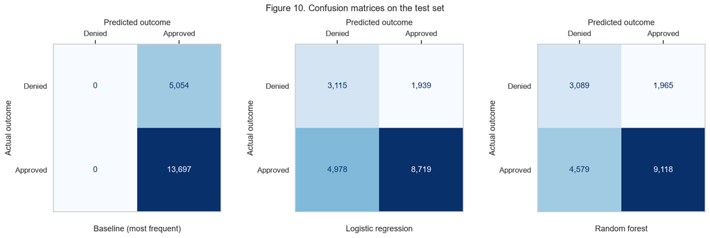

```python
# Create Confusion Matrices for the test set
fig, axes = plt.subplots(1, 3, figsize=(15, 4.8))
for ax, (name, model) in zip(axes, models.items()):
    ConfusionMatrixDisplay.from_estimator(
        model, X_test, y_test, labels=[0, 1], display_labels=["Denied", "Approved"],
        cmap="Blues", colorbar=False, ax=ax, values_format=",")
    # Move the predicted-outcome label and its tick labels to the top
    ax.xaxis.tick_top()
    ax.xaxis.set_label_position("top")
    ax.set_xlabel("Predicted outcome", labelpad=8)
    ax.set_ylabel("Actual outcome")
    # Place the model name below the matrix
    ax.set_title(name, y=-0.14, fontsize=12)
    ax.grid(False)
fig.suptitle("Figure 10. Confusion matrices on the test set", fontsize=13)
plt.tight_layout(); plt.show()
```

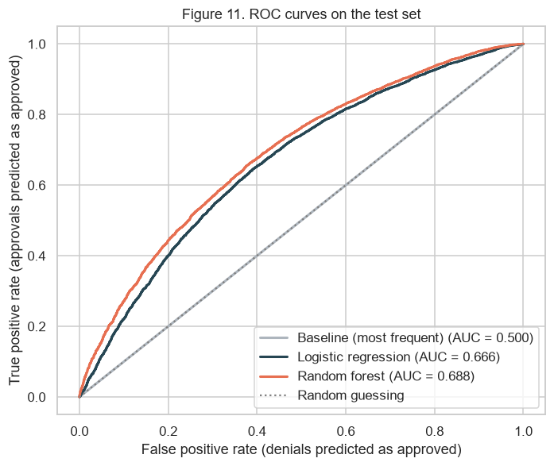

```python
# Create ROC curves for the test set
fig, ax = plt.subplots(figsize=(6.5, 5.5))
colors = {"Baseline (most frequent)": "#adb5bd", "Logistic regression": "#264653", "Random forest": "#e76f51"}
for name, model in models.items():
    fpr, tpr, _ = roc_curve(y_test, model.predict_proba(X_test)[:, 1])
    ax.plot(fpr, tpr, color=colors[name], linewidth=2,
            label=f"{name} (AUC = {results.loc[name, 'ROC-AUC']:.3f})")
ax.plot([0, 1], [0, 1], linestyle=":", color="gray", label="Random guessing")
ax.legend(loc="lower right")
ax.set_title("Figure 11. ROC curves on the test set")
ax.set_xlabel("False positive rate (denials predicted as approved)")
ax.set_ylabel("True positive rate (approvals predicted as approved)")
plt.tight_layout(); plt.show()
```

### 14. Model Interpretation

#### 14.1 Logistic Regression Coefficients

Coefficients are converted to **odds ratios** (e^coefficient). Numeric features are standardized, so their odds ratios describe the effect of a one-standard-deviation increase. An odds ratio above 1 means higher odds of approval; below 1 means lower odds. For one-hot encoded categories, the comparison is relative to the average across categories.

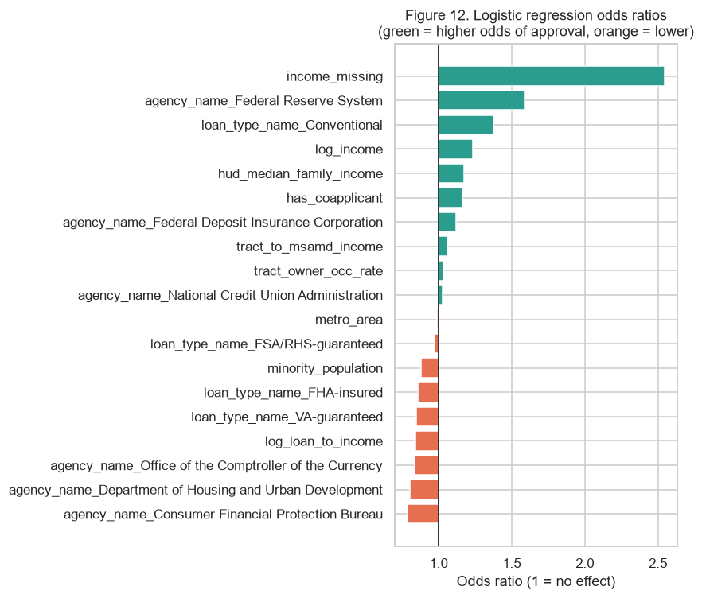

|  | feature | coefficient | odds_ratio |
| --- | --- | --- | --- |
| 0 | income_missing | 0.935 | 2.546 |
| 1 | agency_name_Federal Reserve System | 0.463 | 1.589 |
| 2 | loan_type_name_Conventional | 0.317 | 1.373 |
| 3 | log_income | 0.211 | 1.235 |
| 4 | hud_median_family_income | 0.161 | 1.175 |
| 5 | has_coapplicant | 0.152 | 1.164 |
| 6 | agency_name_Federal Deposit Insurance Corporation | 0.114 | 1.121 |
| 7 | tract_to_msamd_income | 0.059 | 1.061 |
| 8 | tract_owner_occ_rate | 0.034 | 1.034 |
| 9 | agency_name_National Credit Union Administration | 0.029 | 1.029 |
| 10 | metro_area | -0.014 | 0.986 |
| 11 | loan_type_name_FSA/RHS-guaranteed | -0.030 | 0.970 |
| 12 | minority_population | -0.129 | 0.879 |
| 13 | loan_type_name_FHA-insured | -0.154 | 0.857 |
| 14 | loan_type_name_VA-guaranteed | -0.167 | 0.846 |
| 15 | log_loan_to_income | -0.170 | 0.844 |
| 16 | agency_name_Office of the Comptroller of the C... | -0.181 | 0.834 |
| 17 | agency_name_Department of Housing and Urban De... | -0.218 | 0.804 |
| 18 | agency_name_Consumer Financial Protection Bureau | -0.242 | 0.785 |

```python
lr = log_reg_search.best_estimator_
feature_names = (lr.named_steps["pre"].get_feature_names_out()
                 .astype(str))
feature_names = [n.split("__", 1)[1] for n in feature_names]
coefs = pd.DataFrame({"feature": feature_names, "coefficient": lr.named_steps["model"].coef_[0]})
coefs["odds_ratio"] = np.exp(coefs["coefficient"])
coefs = coefs.sort_values("coefficient")

fig, ax = plt.subplots(figsize=(8, 7))
bar_colors = np.where(coefs["coefficient"] > 0, "#2a9d8f", "#e76f51")
ax.barh(coefs["feature"], coefs["odds_ratio"] - 1, left=1, color=bar_colors)
ax.axvline(1, color="black", linewidth=1)
ax.set_title("Figure 12. Logistic regression odds ratios\n(green = higher odds of approval, orange = lower)")
ax.set_xlabel("Odds ratio (1 = no effect)")
plt.tight_layout(); plt.show()

coefs.sort_values("odds_ratio", ascending=False).reset_index(drop=True)
```

##### 14.2 Logistic Regression Coefficient Analysis

- `income_missing` is the single strongest coefficient, which is due to those applicants often being able to utilize a streamlined application process that's likely to be approved.
- I'm surprised `metro_area` is neutral. I assume this is because metro areas are large and have many poor and affluent areas within which cancel each other out.
- I'm surprised that `VA-guaranteed` is negatively coorelated, as I assumed veternas would have streamlined loan access.
- The bottom 3 negative coeficients are all specific agencies, Office of the Comptroller of the Currency, Department of Housing and Urban Development, and the Consumer Financial Bureau.

#### 14.3 Permutation Importance

Permutation importance measures how much the test ROC-AUC drops when one feature's values are randomly shuffled, breaking its relationship with the outcome. It works for any model and is measured on the original features (before one-hot encoding), so the results are easy to compare. A random sample of 10,000 test rows is used to keep computation time reasonable.

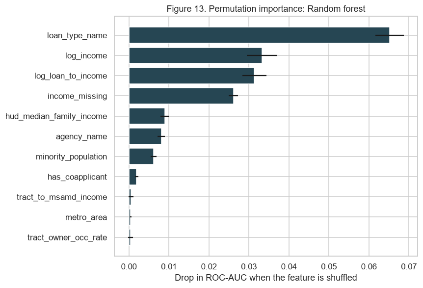

|  | feature | mean_drop_in_auc | std |
| --- | --- | --- | --- |
| 0 | loan_type_name | 0.065 | 0.004 |
| 1 | log_income | 0.033 | 0.004 |
| 2 | log_loan_to_income | 0.031 | 0.003 |
| 3 | income_missing | 0.026 | 0.001 |
| 4 | hud_median_family_income | 0.009 | 0.001 |
| 5 | agency_name | 0.008 | 0.001 |
| 6 | minority_population | 0.006 | 0.001 |
| 7 | has_coapplicant | 0.002 | 0.000 |
| 8 | tract_to_msamd_income | 0.001 | 0.001 |
| 9 | metro_area | 0.000 | 0.000 |
| 10 | tract_owner_occ_rate | 0.000 | 0.001 |

```python
sample = X_test.sample(10_000, random_state=RANDOM_STATE) # Use a sample of the test set to speed up permutation importance calculation
perm = permutation_importance(final_model, sample, y_test.loc[sample.index],
                              scoring="roc_auc", n_repeats=5, random_state=RANDOM_STATE, n_jobs=1)
importance = (pd.DataFrame({"feature": X_test.columns,
                            "mean_drop_in_auc": perm.importances_mean,
                            "std": perm.importances_std})
              .sort_values("mean_drop_in_auc"))

fig, ax = plt.subplots(figsize=(8, 5.5))
ax.barh(importance["feature"], importance["mean_drop_in_auc"], xerr=importance["std"], color="#264653")
ax.set_title(f"Figure 13. Permutation importance: {final_name}")
ax.set_xlabel("Drop in ROC-AUC when the feature is shuffled")
plt.tight_layout(); plt.show()

importance.sort_values("mean_drop_in_auc", ascending=False).reset_index(drop=True)
```

##### 14.4 Permutation Importance Analysis

- `loan_type_name` is the single storngest feature in influence ROC-AUC scores (mean drop of 0.065), which tracks with `lone_type_name_Conventional` being strongly correlated with loan approval, and `loan_type_name_FHA-insured` + `loan_type_name_VA-Guaranteed` corelating with loan denial significantly in the regression model.
- Income fields are the next highest (mean drop of .033, .031, and .026)
- All other fields are below .010

### 15. Fairness audit

The final model does not use race, ethnicity, or sex. This audit checks whether its errors still fall unevenly across groups on the test set.

| Measure | Meaning |
| --- | --- |
| Actual approval rate | Share of the group's applications that lenders approved |
| Predicted approval rate | Share the model predicts will be approved |
| False denial rate | Of applications lenders approved, the share the model predicted would be denied |
| Missed denial rate | Of applications lenders denied, the share the model predicted would be approved |

Groups with fewer than 100 test applications are flagged, since their rates are unreliable.

```python
test_results = groups_test.copy()
test_results["actual"] = y_test
test_results["predicted"] = final_model.predict(X_test)

def group_metrics(data, col):
    rows = []
    for group, g in data.groupby(col):
        approved, denied = g[g["actual"] == 1], g[g["actual"] == 0]
        rows.append({
            col: group,
            "n": len(g),
            "Actual approval rate": g["actual"].mean(),
            "Predicted approval rate": g["predicted"].mean(),
            "False denial rate": (approved["predicted"] == 0).mean(),
            "Missed denial rate": (denied["predicted"] == 1).mean() if len(denied) else np.nan,
            "Accuracy": (g["actual"] == g["predicted"]).mean(),
        })
    out = pd.DataFrame(rows).set_index(col).sort_values("n", ascending=False)
    out["Small group (<100)"] = np.where(out["n"] < 100, "⚠️", "") # Flag small groups for caution in interpreting metrics
    return out

fairness = {col: group_metrics(test_results, col) for col in FAIRNESS_COLS}
fairness["applicant_race_name_1"]
```

| applicant_race_name_1 | n | Actual approval rate | Predicted approval rate | False denial rate | Missed denial rate | Accuracy | Small group (<100) |
| --- | --- | --- | --- | --- | --- | --- | --- |
| White | 12428 | 0.762 | 0.634 | 0.299 | 0.420 | 0.672 |  |
| Not provided | 2941 | 0.696 | 0.558 | 0.383 | 0.424 | 0.604 |  |
| Black or African American | 2826 | 0.637 | 0.435 | 0.470 | 0.268 | 0.603 |  |
| Asian | 344 | 0.721 | 0.706 | 0.206 | 0.479 | 0.718 |  |
| American Indian or Alaska Native | 164 | 0.591 | 0.421 | 0.495 | 0.299 | 0.585 |  |
| Native Hawaiian or Other Pacific Islander | 40 | 0.675 | 0.500 | 0.370 | 0.231 | 0.675 | ⚠️ |
| Not applicable | 8 | 0.750 | 0.500 | 0.500 | 0.500 | 0.500 | ⚠️ |

```python
fairness["applicant_ethnicity_name"]
```

| applicant_ethnicity_name | n | Actual approval rate | Predicted approval rate | False denial rate | Missed denial rate | Accuracy | Small group (<100) |
| --- | --- | --- | --- | --- | --- | --- | --- |
| Not Hispanic or Latino | 15356 | 0.740 | 0.600 | 0.323 | 0.382 | 0.661 |  |
| Not provided | 2723 | 0.689 | 0.559 | 0.381 | 0.427 | 0.605 |  |
| Hispanic or Latino | 660 | 0.671 | 0.509 | 0.418 | 0.359 | 0.602 |  |
| Not applicable | 12 | 0.750 | 0.417 | 0.556 | 0.333 | 0.500 | ⚠️ |

```python
fairness["applicant_sex_name"]
```

| applicant_sex_name | n | Actual approval rate | Predicted approval rate | False denial rate | Missed denial rate | Accuracy | Small group (<100) |
| --- | --- | --- | --- | --- | --- | --- | --- |
| Male | 11396 | 0.744 | 0.614 | 0.309 | 0.391 | 0.670 |  |
| Female | 5413 | 0.719 | 0.556 | 0.371 | 0.367 | 0.630 |  |
| Not provided | 1927 | 0.683 | 0.555 | 0.389 | 0.433 | 0.597 |  |
| Not applicable | 15 | 0.867 | 0.600 | 0.385 | 0.500 | 0.600 | ⚠️ |

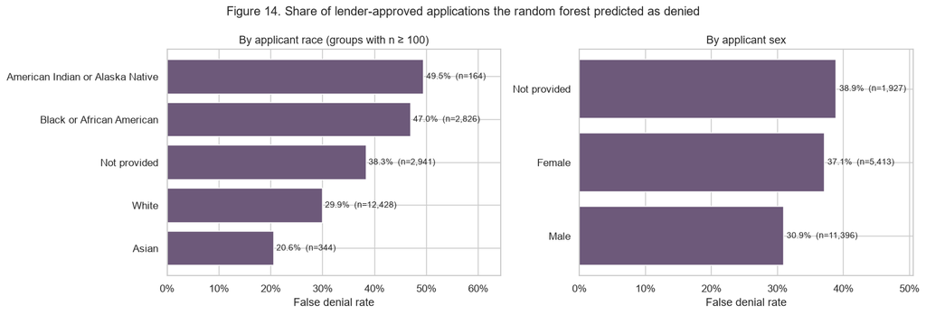

```python
fig, axes = plt.subplots(1, 2, figsize=(14, 4.8))
race = fairness["applicant_race_name_1"].drop(index="Not applicable", errors="ignore")
race = race[race["n"] >= 100].sort_values("False denial rate")
sex = fairness["applicant_sex_name"].drop(index="Not applicable", errors="ignore").sort_values("False denial rate")

for ax, data, title in [(axes[0], race, "By applicant race (groups with n ≥ 100)"),
                        (axes[1], sex, "By applicant sex")]:
    ax.barh(data.index, data["False denial rate"], color="#6d597a")
    for i, (v, n) in enumerate(zip(data["False denial rate"], data["n"])):
        ax.text(v + 0.005, i, f"{v:.1%}  (n={n:,})", va="center", fontsize=9)
    ax.xaxis.set_major_formatter(mtick.PercentFormatter(1, decimals=0))
    ax.set_xlim(0, data["False denial rate"].max() * 1.3)
    ax.set_title(title); ax.set_xlabel("False denial rate"); ax.set_ylabel("")
fig.suptitle(f"Figure 14. Share of lender-approved applications the {final_name.lower()} predicted as denied",
             fontsize=13)
plt.tight_layout(); plt.show()
```

Theories on factors which correlate with race for this data:

- Men are more likely to be the primary income source of a household, and there is a large disparity in the number of male applicants vs female (~11k vs ~5k).
- American Indian or Alaska Natives may be disproportionately concentrated in poorer regions in North Carolina, potentially related to the notorious poverty that exists on American reservation land elsewhere.
- Black minorities are likely to be in lower income neighborhoods, potentially related to past Jim Crow history in North Carolina.
- Asian minorities may be disproportionally concentrated in affluent areas in North Carolina such as the Research Triangle area.

### 16. Comparison model with demographics (Model B)

To measure whether demographic characteristics are associated with approval *after* accounting for the other features, a second logistic regression adds race, ethnicity, and sex as one-hot encoded features.

> ⚖️ This model is for **measurement only**. Using race, ethnicity, or sex in real lending decisions is prohibited by the Equal Credit Opportunity Act. And because credit score and debt-to-income are missing from the data, demographic coefficients here **cannot prove discrimination**: they may partly reflect those unmeasured factors.

```python
X_train_b = X_train.join(groups_train)
X_test_b = X_test.join(groups_test)

model_b = Pipeline([
    ("pre", make_preprocessor(APPROVAL_NUMERIC, APPROVAL_BINARY, CATEGORICAL + FAIRNESS_COLS)),
    ("model", LogisticRegression(class_weight="balanced", max_iter=2000,
                                 C=log_reg_search.best_params_["model__C"])),
])
model_b.fit(X_train_b, y_train)

comparison = pd.DataFrame({
    "Model A: without demographics": evaluate(log_reg_search.best_estimator_, X_test, y_test),
    "Model B: with demographics": evaluate(model_b, X_test_b, y_test),
}).T
comparison
```

|  | Accuracy | Balanced accuracy | ROC-AUC | Denial precision | Denial recall | Denial F1 |
| --- | --- | --- | --- | --- | --- | --- |
| Model A: without demographics | 0.631 | 0.626 | 0.666 | 0.385 | 0.616 | 0.474 |
| Model B: with demographics | 0.637 | 0.633 | 0.672 | 0.391 | 0.623 | 0.481 |

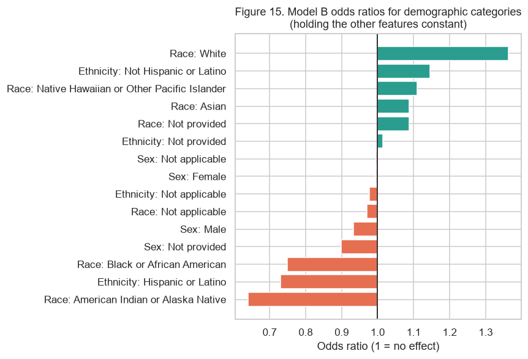

|  | feature | coefficient | odds_ratio |
| --- | --- | --- | --- |
| 0 | Race: White | 0.310 | 1.364 |
| 1 | Ethnicity: Not Hispanic or Latino | 0.136 | 1.146 |
| 2 | Race: Native Hawaiian or Other Pacific Islander | 0.104 | 1.109 |
| 3 | Race: Asian | 0.084 | 1.088 |
| 4 | Race: Not provided | 0.083 | 1.087 |
| 5 | Ethnicity: Not provided | 0.015 | 1.015 |
| 6 | Sex: Not applicable | -0.004 | 0.996 |
| 7 | Sex: Female | -0.005 | 0.995 |
| 8 | Ethnicity: Not applicable | -0.023 | 0.977 |
| 9 | Race: Not applicable | -0.031 | 0.970 |
| 10 | Sex: Male | -0.069 | 0.933 |
| 11 | Sex: Not provided | -0.107 | 0.898 |
| 12 | Race: Black or African American | -0.290 | 0.749 |
| 13 | Ethnicity: Hispanic or Latino | -0.314 | 0.731 |
| 14 | Race: American Indian or Alaska Native | -0.447 | 0.640 |

```python
names_b = [n.split("__", 1)[1] for n in model_b.named_steps["pre"].get_feature_names_out().astype(str)]
coefs_b = pd.DataFrame({"feature": names_b, "coefficient": model_b.named_steps["model"].coef_[0]})
coefs_b["odds_ratio"] = np.exp(coefs_b["coefficient"])
demo = coefs_b[coefs_b["feature"].str.startswith(tuple(FAIRNESS_COLS))].copy()
demo["feature"] = (demo["feature"]
                   .str.replace("applicant_race_name_1_", "Race: ")
                   .str.replace("applicant_ethnicity_name_", "Ethnicity: ")
                   .str.replace("applicant_sex_name_", "Sex: "))
demo = demo.sort_values("odds_ratio")

fig, ax = plt.subplots(figsize=(8, 5.5))
ax.barh(demo["feature"], demo["odds_ratio"] - 1, left=1,
        color=np.where(demo["odds_ratio"] > 1, "#2a9d8f", "#e76f51"))
ax.axvline(1, color="black", linewidth=1)
ax.set_title("Figure 15. Model B odds ratios for demographic categories\n(holding the other features constant)")
ax.set_xlabel("Odds ratio (1 = no effect)")
plt.tight_layout(); plt.show()

demo.sort_values("odds_ratio", ascending=False).reset_index(drop=True)
```

### Summary of results

```python
summary = results.loc[:, ["Accuracy", "Balanced accuracy", "ROC-AUC", "Denial recall", "Denial F1"]]
print(f"Final model: {final_name}")
print(f"Test ROC-AUC: {results.loc[final_name, 'ROC-AUC']:.3f} "
      f"(baseline {results.loc['Baseline (most frequent)', 'ROC-AUC']:.3f})")
print(f"Denials caught (recall): {results.loc[final_name, 'Denial recall']:.1%}")
summary
```

```
Final model: Random forest
Test ROC-AUC: 0.688 (baseline 0.500)
Denials caught (recall): 61.1%
```

|  | Accuracy | Balanced accuracy | ROC-AUC | Denial recall | Denial F1 |
| --- | --- | --- | --- | --- | --- |
| Baseline (most frequent) | 0.730 | 0.500 | 0.500 | 0.000 | 0.000 |
| Logistic regression | 0.631 | 0.626 | 0.666 | 0.616 | 0.474 |
| Random forest | 0.651 | 0.638 | 0.688 | 0.611 | 0.486 |